# Laboratorium 3

Celem trzeciego laboratorium jest zapoznanie się oraz zaimplementowanie algorytmów uczenia aktywnego. Zaimplementowane algorytmy będą testowane z wykorzystaniem wcześniej przygotowanych środowisk.

Dołączenie standardowych bibliotek

```python
import random
import matplotlib.pyplot as plt
import numpy as np
from itertools import compress
from tqdm import tqdm
from collections import defaultdict
from numpy import trapz
```

Dołączenie bibliotek ze środowiskami

```python
from env.dqnSimpleMDP import dqnSimpleMDP
from env.CliffWorldMDP import CliffWorld
from QLearningAgent import QLearningAgent
```

## Zadanie 1 - SARSA($\lambda$)

Celem ćwiczenie jest zaimplementowanie algorytmu SARSA. Algorytm aktualizuje funkcję wartości stanu-akcji dla każdej odwiedzonej pary stan-akcja zgodnie ze wzorem: \begin{equation} Q_{t + 1}(s, a) = Q_t(s, a) + \alpha \delta_t E_t(s, a) \end{equation} gdzie: - $\delta_t = r_{t + 1} \gamma Q_t(s_{t + 1}, a_{t + 1}) - Q_t(s_{t}, a_{t})$, - $E_t(s, a)$ - ślad dla pary stan - akcja w chwili czasowej $t$, zwiększany o $1$ w chwili odwiedzenia danego stanu.

```python
import random
from collections import defaultdict


class SARSALambdaAgent:
    def __init__(self, alpha, epsilon, discount, get_legal_actions, lambda_value):
        """
        Q-Learning Agent
        based on https://inst.eecs.berkeley.edu/~cs188/sp19/projects.html
        Instance variables you have access to
          - self.epsilon (exploration prob)
          - self.alpha (learning rate)
          - self.discount (discount rate aka gamma)

        Functions you should use
          - self.get_legal_actions(state) {state, hashable -> list of actions, each is hashable}
            which returns legal actions for a state
          - self.get_qvalue(state,action)
            which returns Q(state,action)
          - self.set_qvalue(state,action,value)
            which sets Q(state,action) := value
        !!!Important!!!
        Note: please avoid using self._qValues directly.
            There's a special self.get_qvalue/set_qvalue for that.
        """

        self.get_legal_actions = get_legal_actions
        self._qvalues = defaultdict(lambda: defaultdict(lambda: 0))
        self._evalues = defaultdict(lambda: defaultdict(lambda: 0))
        self.alpha = alpha
        self.epsilon = epsilon
        self.discount = discount
        self.lambda_value = lambda_value

    def get_qvalue(self, state, action):
        """ Returns Q(state,action) """
        return self._qvalues[state][action]

    def set_qvalue(self, state, action, value):
        """ Sets the Qvalue for [state,action] to the given value """
        self._qvalues[state][action] = value

    def get_evalue(self, state, action):
        """ Returns E(state,action) """
        return self._evalues[state][action]

    def set_evalue(self, state, action, value):
        """ Sets the Qvalue for [state,action] to the given value """
        self._evalues[state][action] = value

    def reset(self):
        self._evalues = defaultdict(lambda: defaultdict(lambda: 0))

    # ---------------------START OF YOUR CODE---------------------#

    def get_value(self, state):
        """
        Compute your agent's estimate of V(s) using current q-values
        V(s) = max_over_action Q(state,action) over possible actions.
        Note: please take into account that q-values can be negative.
        """
        possible_actions = self.get_legal_actions(state)

        # If there are no legal actions, return 0.0
        if len(possible_actions) == 0:
            return 0.0

        return max([self.get_qvalue(state, a) for a in possible_actions])

    def update(self, state, action, reward, next_state):
        """
        You should do your SARSA-Lambda update here:
        """
        # Replacing traces were used
        self.set_evalue(state, action, 1) # set to 1

        # agent parameters
        gamma = self.discount
        learning_rate = self.alpha
        lambda_step = self.lambda_value

        a_prim = self.get_action(next_state)
        delta = reward + gamma * self.get_qvalue(next_state, a_prim) - self.get_qvalue(state, action)

        # not computationaly optimal - but works :D
        for s in self._evalues.keys(): # iterate over states
            for a in self._evalues[s].keys(): # over actions in states
                v = self.get_evalue(s, a)
                if v > 0.001: # do not choose those very close to 0
                    self.set_qvalue(s, a, self.get_qvalue(s, a) + learning_rate*delta*v)
                    self.set_evalue(s, a, lambda_step*gamma*v)

        return a_prim

    def get_best_action(self, state):
        """
        Compute the best action to take in a state (using current q-values).
        """
        possible_actions = self.get_legal_actions(state)

        # If there are no legal actions, return None
        if len(possible_actions) == 0:
            return None

        q_values = [self.get_qvalue(state, a) for a in possible_actions]
        highest_value = max(q_values)
        actions = [id for id, val in enumerate(q_values) if val == highest_value]

        return random.choice(actions)

    def get_action(self, state):
        """
        Compute the action to take in the current state, including exploration.
        With probability self.epsilon, we should take a random action.
            otherwise - the best policy action (self.get_best_action).

        Note: To pick randomly from a list, use random.choice(list).
              To pick True or False with a given probablity, generate uniform number in [0, 1]
              and compare it with your probability
        """

        # Pick Action
        possible_actions = self.get_legal_actions(state)

        # If there are no legal actions, return None
        if len(possible_actions) == 0:
            return None

        # agent parameters:
        epsilon = self.epsilon

        if epsilon and (random.uniform(0, 1) < epsilon):
            chosen_action = random.choice(possible_actions)
        else:
            chosen_action = self.get_best_action(state)

        return chosen_action

    def turn_off_learning(self):
        self.epsilon = 0
        self.alpha = 0

    def display_qvalues(self):
        for s in self._qvalues:
            print("State: " + str(s) + " " + str(self._qvalues[s]))
```

Czas nauczyć agenta poruszania się po dowolnym środowisku:

```python
def play_and_train(env, agent):
    """
    This function should
    - run a full game, actions given by agent's e-greedy policy
    - train agent using agent.update(...) whenever it is possible
    - return total reward
    """
    total_reward = 0.0
    state = env.reset()

    done = False

    agent.reset() # important to reset evalues
    action = agent.get_action(state)

    while not done:
        next_state, reward, done, _ = env.step(action)
        # use the action determined in update method
        action = agent.update(state, action, reward, next_state)

        state = next_state
        total_reward += reward
        if done:
            break

    return total_reward
```

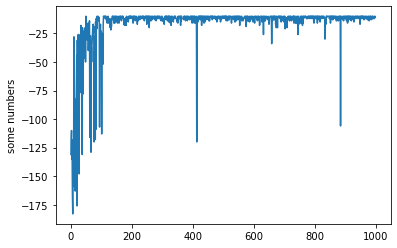

```python
environment = CliffWorld()
agent = SARSALambdaAgent(alpha=0.1, epsilon=0.1, discount=0.99,
                   get_legal_actions=environment.get_possible_actions, lambda_value = 0.5)

rewards = []
for i in range(1000):
    rewards.append(play_and_train(environment, agent))

plt.plot(rewards)
plt.ylabel('some numbers')
plt.show()
```

## Zadanie 2 - Double Q-Learning

Celem ćwiczenie jest zaimplementowanie algorytmu Double Q-Learning. Algorytm aktualizuje funkcję wartości stanu-akcji zgodnie ze wzorami: \begin{equation*} Q_1(s_t, a_t) = Q_1(s_t, a_t) + \alpha[r_{t+1} + \gamma Q_2(argmax_a(Q_1(s_{t + 1}, a))) - Q_1(s_t, a_t)] \end{equation*} \begin{equation*} Q_2(s_t, a_t) = Q_2(s_t, a_t) + \alpha[r_{t+1} + \gamma Q_1(argmax_a(Q_2(s_{t + 1}, a))) - Q_2(s_t, a_t)] \end{equation*} z prawdopodobieństwem wyboru każdej z opcji równym 50%.

```python
class DQLearningAgent:
    def __init__(self, alpha, epsilon, discount, get_legal_actions):
        """
        Q-Learning Agent
        based on https://inst.eecs.berkeley.edu/~cs188/sp19/projects.html
        Instance variables you have access to
          - self.epsilon (exploration prob)
          - self.alpha (learning rate)
          - self.discount (discount rate aka gamma)
        """

        self.get_legal_actions = get_legal_actions
        self._qvaluesA = defaultdict(lambda: defaultdict(lambda: 0))
        self._qvaluesB = defaultdict(lambda: defaultdict(lambda: 0))
        self.alpha = alpha
        self.epsilon = epsilon
        self.discount = discount


    #---------------------START OF YOUR CODE---------------------#

    def get_qvalue(self, state, action, qval = None):
        """ Returns Q(state,action) """
        if qval:
            return qval[state][action] # value for particular qvalues table
        return (self._qvaluesA[state][action] + self._qvaluesB[state][action])/2 # for statistics use average

    def set_qvalue(self, state, action, value, qval):
        """ Sets the Qvalue for [state,action] to the given value """
        qval[state][action] = value

    def get_best_action(self, state, qval = None):
        """
        Compute the best action to take in a state (using current q-values).
        """
        possible_actions = self.get_legal_actions(state)

        # If there are no legal actions, return None
        if len(possible_actions) == 0:
            return None

        # From one
        if qval:
            values = [self.get_qvalue(state, a, qval) for a in possible_actions]
        # From both
        else:
            values_A = [self.get_qvalue(state, a, self._qvaluesA) for a in possible_actions]
            values_B = [self.get_qvalue(state, a, self._qvaluesB) for a in possible_actions]
            # Sum them
            values = [sum(x) for x in zip(values_A, values_B)]

        # Select action corresponding to the highest value
        max_val = max(values)
        # Just in case there are multiple actions with this value
        is_potential_action = [val == max_val for val in values]
        actions_filtered = list(compress(possible_actions, is_potential_action))

        return random.choice(actions_filtered)


    def update(self, state, action, reward, next_state):
        """
        You should do your Q-Value update here
        """

        # agent parameters
        gamma = self.discount
        learning_rate = self.alpha

        # agent parameters
        gamma = self.discount
        learning_rate = self.alpha

        # which qval
        if random.choice([True, False]):
            qval_1 = self._qvaluesA
            qval_2 = self._qvaluesB
        else:
            qval_1 = self._qvaluesB
            qval_2 = self._qvaluesA

        action_from_qval_1 = self.get_best_action(next_state, qval_1)

        value = self.get_qvalue(state, action, qval_1) + learning_rate * \
            (reward + gamma * self.get_qvalue(next_state, action_from_qval_1, qval_2) - self.get_qvalue(state, action, qval_1))

        self.set_qvalue(state, action, value, qval_1)


    def get_action(self, state):
        """
        Compute the action to take in the current state, including exploration.
        With probability self.epsilon, we should take a random action.
            otherwise - the best policy action (self.get_best_action).

        Note: To pick randomly from a list, use random.choice(list).
              To pick True or False with a given probablity, generate uniform number in [0, 1]
              and compare it with your probability
        """

        # Pick Action
        possible_actions = self.get_legal_actions(state)

        # If there are no legal actions, return None
        if len(possible_actions) == 0:
            return None

        # agent parameters:
        epsilon = self.epsilon

        if epsilon and (random.uniform(0, 1) < epsilon):
            chosen_action = random.choice(possible_actions)
        else:
            chosen_action = self.get_best_action(state)

        return chosen_action

    def turn_off_learning(self):
        self.epsilon = 0
        self.alpha = 0
```

```python
env = dqnSimpleMDP()

max_tests = 10000
n_eps = 300
eps = 0.1
lr = 0.1


left_count_q = np.zeros(n_eps) #count left choices in state A for algorithm Q-Learning
left_count_dq = np.zeros(n_eps) #count left choices in state A for algorithm Double Q-Learning

q_estimate = np.zeros(n_eps) #store value estimation for choosing action left in left choices in state A for algorithm Q-Learning
dq_estimate = np.zeros(n_eps) #store value estimation for choosing action left in left choices in state A for algorithm Double Q-Learning
```

```python
t = 0
s_1 = None
while t < max_tests:

    Q = {state: np.zeros(env.max_actions) for state in env.state_actions.keys()}
    agent = QLearningAgent(alpha=0.1, epsilon=0.1, discount=1,
                           get_legal_actions=env.get_possible_actions)
    for ep in range(n_eps):
        state = env.reset()
        while True:
            # Select eps-greedy action
            action = agent.get_action(state)

            # Count left actions from A
            if state == 'A' and action == 1:
                left_count_q[ep] += 1

            next_state, reward, done, _ = env.step(action)

            agent.update(state, action, reward, next_state)

            state = next_state
            if done:
                q_estimate[ep] += agent.get_qvalue('A', 1)

                break
    t += 1

q_estimate /= max_tests
```

```python
t = 0
while t < max_tests:

    agent = DQLearningAgent(alpha=0.1, epsilon=0.1, discount=1,
                            get_legal_actions=env.get_possible_actions)
    for ep in range(n_eps):
        state = env.reset()
        while True:
            # Select eps-greedy action
            action = agent.get_action(state)

            # Count left actions from A
            if state == 'A' and action == 1:
                left_count_dq[ep] += 1

            next_state, reward, done, _ = env.step(action)

            agent.update(state, action, reward, next_state)

            state = next_state
            if done:
                dq_estimate[ep] += agent.get_qvalue('A', 1) #/ 2 Ale nie u mnie, ja już sobie sam dzielę, ha!

                break
    t += 1

dq_estimate /= max_tests
```

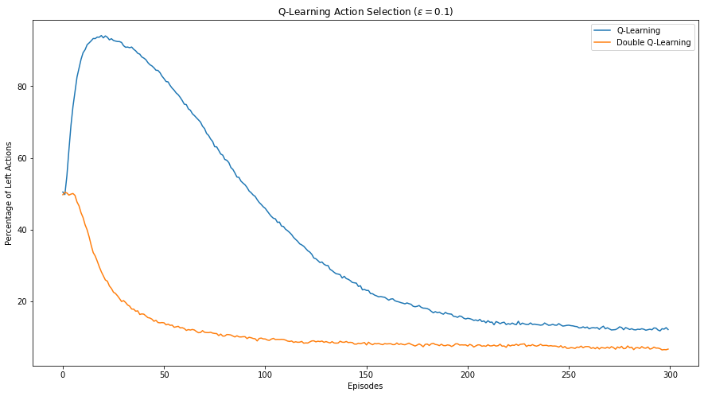

```python
plt.figure(figsize=(15,8))
plt.plot(left_count_q/max_tests*100,
         label='Q-Learning')
plt.plot(left_count_dq/max_tests*100,
         label='Double Q-Learning')
plt.ylabel('Percentage of Left Actions')
plt.xlabel('Episodes')
plt.title(r'Q-Learning Action Selection ($\epsilon=0.1$)')
plt.legend(loc='best')
plt.show()
```

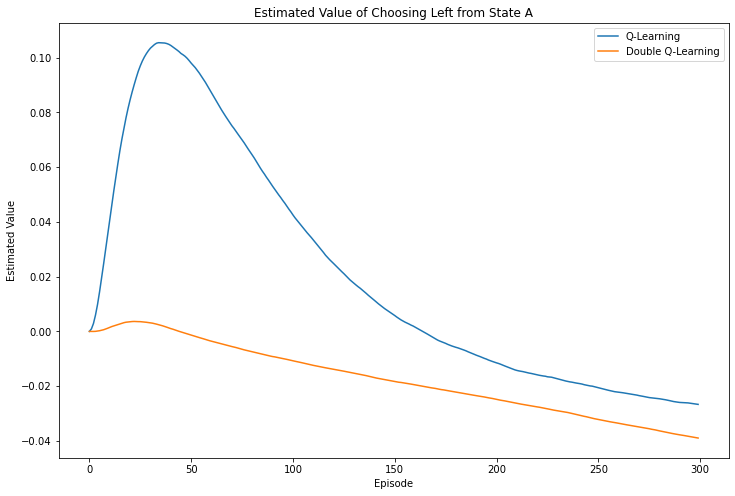

```python
plt.figure(figsize=(12,8))
plt.plot(q_estimate, label='Q-Learning')
plt.plot(dq_estimate, label='Double Q-Learning')

plt.legend()
plt.xlabel('Episode')
plt.ylabel('Estimated Value')
plt.title('Estimated Value of Choosing Left from State A')
plt.show()
```

## Zadanie 3

Przetestuj działanie wszystkich zaimplementowanych algorytmów w środowisku dqnSimpleMDP, który algorytm działa najlepiej?

```python
from QLearningAgent import *
from ExpectedSARSAAgent import *
from SARSAAgent import *
```

```python
env = dqnSimpleMDP()
```

```python
iterations_train = 100000
iterations_test = 1000
```

### QLearning

```python
agentQL = QLearningAgent(alpha=0.5, epsilon=0.25, discount=0.99,
                       get_legal_actions=env.get_possible_actions)

agentQL_training = []
agentQL_results = []
agentQL_LA = []

for i in range(iterations_train):
    agentQL_training.append(Q_play_and_train(env, agentQL))
    agentQL_LA.append(agentQL.get_qvalue('A', 1))

agentQL.turn_off_learning()

for i in range(iterations_test):
    agentQL_results.append(Q_play_and_train(env, agentQL))
```

### SARSA

```python
agentS = SARSAAgent(alpha=0.1, epsilon=0.1, discount=0.99,
                   get_legal_actions=env.get_possible_actions)

agentS_training = []
agentS_results = []
agentS_LA = []

for i in range(iterations_train):
    agentS_training.append(S_play_and_train(env, agentS))
    agentS_LA.append(agentS.get_qvalue('A', 1))


agentS.turn_off_learning()

for i in range(iterations_test):
    agentS_results.append(S_play_and_train(env, agentS))
```

### ExpectedSARSA

```python
agentES = ExpectedSARSAAgent(alpha=0.1, epsilon=0.1, discount=0.99,
                   get_legal_actions=env.get_possible_actions)

agentES_training = []
agentES_results = []
agentES_LA = []

for i in range(iterations_train):
    agentES_training.append(ES_play_and_train(env, agentES))
    agentES_LA.append(agentES.get_qvalue('A', 1))


agentES.turn_off_learning()

for i in range(iterations_test):
    agentES_results.append(ES_play_and_train(env, agentES))
```

### SARSALambda

```python
agentSL = SARSALambdaAgent(alpha=0.1, epsilon=0.1, discount=0.99,
                   get_legal_actions=env.get_possible_actions, lambda_value = 0.5)

agentSL_training = []
agentSL_results = []
agentSL_LA = []

for i in range(iterations_train):
    agentSL_training.append(play_and_train(env, agentSL))
    agentSL_LA.append(agentSL.get_qvalue('A', 1))


agentSL.turn_off_learning()

for i in range(iterations_test):
    agentSL_results.append(play_and_train(env, agentSL))
```

### Double Q-Learning

```python
def DQ_play_and_train(env, agent):
    state = env.reset()
    total_reward = 0
    done = False
    while not done:
        action = agent.get_action(state)

        next_state, reward, done, _ = env.step(action)
        total_reward = total_reward + reward

        agent.update(state, action, reward, next_state)

        state = next_state

    return total_reward
```

```python
agentDQ = DQLearningAgent(alpha=0.1, epsilon=0.1, discount=1,
                        get_legal_actions=env.get_possible_actions)

agentDQ_training = []
agentDQ_results = []
agentDQ_LA = []

for i in range(iterations_train):
    agentDQ_training.append(DQ_play_and_train(env, agentDQ))
    agentDQ_LA.append(agentDQ.get_qvalue('A', 1))


agentDQ.turn_off_learning()

for i in range(iterations_test):
    agentDQ_results.append(DQ_play_and_train(env, agentDQ))
```

### RESULTS

#### Training

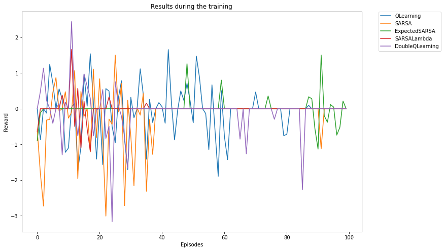

```python
fig, ax = plt.subplots(figsize=(12, 8))
ax.plot(agentQL_training[:100], label = "QLearning")
ax.plot(agentS_training[:100], label = "SARSA")
ax.plot(agentES_training[:100], label = "ExpectedSARSA")
ax.plot(agentSL_training[:100], label = "SARSALambda")
ax.plot(agentDQ_training[:100], label = "DoubleQLearning")

ax.set(xlabel='Episodes', ylabel='Reward',
       title="Results during the training")
plt.legend(bbox_to_anchor=(1.05, 1), loc='upper left', borderaxespad=0.)
```

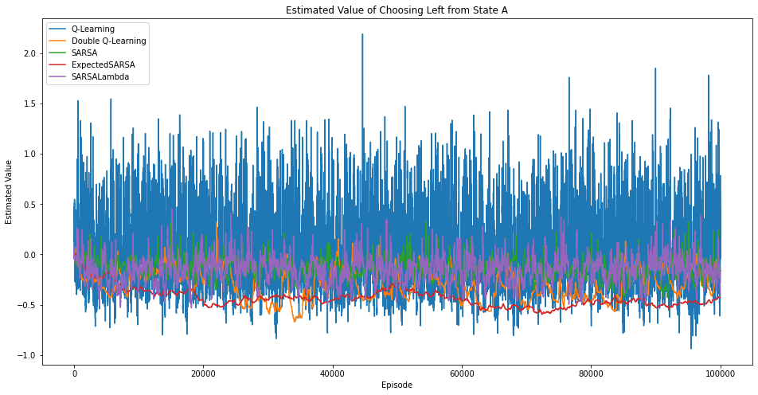

```python
plt.figure(figsize=(16,8))
plt.plot(agentQL_LA, label='Q-Learning')
plt.plot(agentDQ_LA, label='Double Q-Learning')
plt.plot(agentS_LA, label='SARSA')
plt.plot(agentES_LA, label='ExpectedSARSA')
plt.plot(agentSL_LA, label='SARSALambda')

plt.legend()
plt.xlabel('Episode')
plt.ylabel('Estimated Value')
plt.title('Estimated Value of Choosing Left from State A')
plt.show()
```

#### Testing

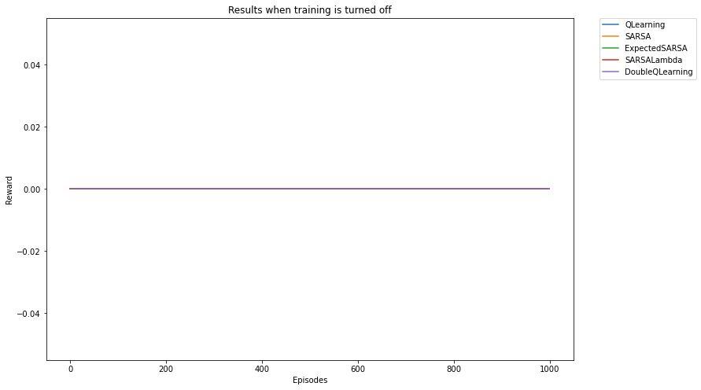

```python
fig, ax = plt.subplots(figsize=(12, 8))
ax.plot(agentQL_results, label = "QLearning")
ax.plot(agentS_results, label = "SARSA")
ax.plot(agentES_results, label = "ExpectedSARSA")
ax.plot(agentSL_results, label = "SARSALambda")
ax.plot(agentDQ_results, label = "DoubleQLearning")

ax.set(xlabel='Episodes', ylabel='Reward',
       title="Results when training is turned off")
plt.legend(bbox_to_anchor=(1.05, 1), loc='upper left', borderaxespad=0.)
```

## Wnioski

- Na podstawie szacowanej wartości odpowiedzialnej za wybranie akcji w lewo w stanie początkowym, najlepszymi algorytmami wydają się być Double Q-learning i Excpected SARSA.
- Zdecydowanie najgorzej prezentuje się Q-Learning co widać przy jego wahania przy wartości Q_value odpowiedzialnej za wybieranie akcji ruchu w lewo.
- Wszystkie wersje algorytmu SARSA są w stanie stosunkowo poprawnie estymować wartość Q_value.
- Poprzez testowanie z odpowiednimi hiperparametrami dałoby się zapewne osiągnąć lepsze efekty.
- Naturalnie przy tak prostym modelu po wyłączeniu procesu uczenia, wszystkie algorytmy potrafią osiągnąć optymalną nagrodę.